# Project Python Foundations: FoodHub Data Analysis

### **Question 15:** The company wants to analyze the total time required to deliver the food. What percentage of orders take more than 60 minutes to get delivered from the time the order is placed? (The food has to be prepared and then delivered.) [2 marks]

```python
# Write the code here

data['total_time'] = data['food_preparation_time'] + data['delivery_time']

# Step 2: Count how many orders take more than 60 minutes
orders_over_60 = data[data['total_time'] > 60].shape[0]

# Step 3: Calculate percentage
total_orders = data.shape[0]
percent_over_60 = (orders_over_60 / total_orders) * 100

print(f"Orders taking more than 60 minutes: {orders_over_60} ({percent_over_60:.2f}%)")
```

```
Orders taking more than 60 minutes: 200 (10.54%)
```

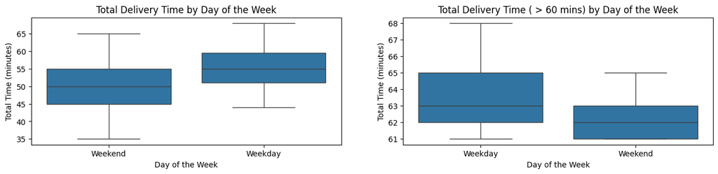

```
  day_of_the_week  Order Count (Total Time > 60)
0         Weekday                            119
1         Weekend                             81
```

```python
# total time corelation with day of the week
fig, axes = plt.subplots(1, 2, figsize=(16,3))

sns.boxplot(x='day_of_the_week', y='total_time', data=data, ax=axes[0])
axes[0].set_title('Total Delivery Time by Day of the Week')
axes[0].set_xlabel('Day of the Week')
axes[0].set_ylabel('Total Time (minutes)')

sns.boxplot(x='day_of_the_week', y='total_time', data= data[data['total_time'] > 60], ax=axes[1])
axes[1].set_title('Total Delivery Time ( > 60 mins) by Day of the Week')
axes[1].set_xlabel('Day of the Week')
axes[1].set_ylabel('Total Time (minutes)')
plt.show()

data_over_60 = data[data['total_time'] > 60]

# Count how many such orders occur by day of the week
orders_over_60_by_day = (
    data_over_60.groupby('day_of_the_week')['total_time']
    .count()
    .reset_index()
    .rename(columns={'total_time': 'Order Count (Total Time > 60)'})
)

print(orders_over_60_by_day)
```

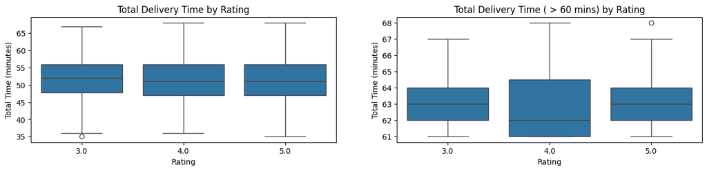

```
   rating  Order Count (Total Time > 60)
0     3.0                             19
1     4.0                             39
2     5.0                             61
```

```python
# total time corelation with rating
fig, axes = plt.subplots(1, 2, figsize=(16,3))

sns.boxplot(x='rating', y='total_time', data=data, ax=axes[0])
axes[0].set_title('Total Delivery Time by Rating')
axes[0].set_xlabel('Rating')
axes[0].set_ylabel('Total Time (minutes)')

sns.boxplot(x='rating', y='total_time', data= data[data['total_time'] > 60], ax=axes[1])
axes[1].set_title('Total Delivery Time ( > 60 mins) by Rating')
axes[1].set_xlabel('Rating')
axes[1].set_ylabel('Total Time (minutes)')
plt.show()

data_over_60 = data[data['total_time'] > 60]

# Count how many such orders occur by day of the week
orders_over_60_by_rating = (
    data_over_60.groupby('rating')['total_time']
    .count()
    .reset_index()
    .rename(columns={'total_time': 'Order Count (Total Time > 60)'})
)

print(orders_over_60_by_rating)
```

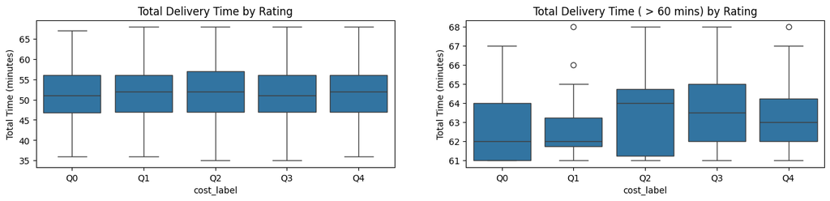

```
  cost_label  Order Count (Total Time > 60)
0         Q0                             56
1         Q1                             32
2         Q2                             30
3         Q3                             30
4         Q4                             52
```

```python
# total time corelation with cost of the order
fig, axes = plt.subplots(1, 2, figsize=(16,3))
data['cost_label'] = pd.cut(
   data['cost_of_the_order'],
   bins=[4, 12, 14, 16, 22, 36],
   labels=['Q0', 'Q1', 'Q2', 'Q3', 'Q4'],
   right=False
)

sns.boxplot(x='cost_label', y='total_time', data=data, ax=axes[0])
axes[0].set_title('Total Delivery Time by Rating')
axes[0].set_xlabel('cost_label')
axes[0].set_ylabel('Total Time (minutes)')

sns.boxplot(x='cost_label', y='total_time', data= data[data['total_time'] > 60], ax=axes[1])
axes[1].set_title('Total Delivery Time ( > 60 mins) by Rating')
axes[1].set_xlabel('cost_label')
axes[1].set_ylabel('Total Time (minutes)')
plt.show()

data_over_60 = data[data['total_time'] > 60]

# Count how many such orders occur by day of the week
orders_over_60_by_rating = (
    data_over_60.groupby('cost_label')['total_time']
    .count()
    .reset_index()
    .rename(columns={'total_time': 'Order Count (Total Time > 60)'})
)

print(orders_over_60_by_rating)
```

#### Observations:

- there are a total of 200 orders around 10% of the orders are taking over 60 mins of total time
- Out of all orders taking more than 60 minutes, 119 occurred on weekdays and 81 on weekends.
- Although weekends generally have a higher total number of orders, a greater number of long-duration deliveries happen on weekdays.
- This suggests that weekday operations experience slightly more delays, possibly due to factors like traffic congestion, peak office-hour deliveries, or restaurant workload during lunch hours.
- Overall, the difference is moderate, indicating that while service efficiency remains stable, there may be room to optimize weekday delivery performance.
- Among the delayed orders (total time > 60 minutes), most have higher ratings — 61 rated 5 and 39 rated 4 — indicating that longer delivery times did not significantly impact customer satisfaction.
- The distribution of delayed orders (total time > 60 minutes) is fairly balanced across cost ranges, with slightly higher counts in the lowest (Q0) and highest (Q4) price segments. This suggests that order cost does not strongly influence delivery delays, as both low- and high-value orders experience similar wait times.